# Week 3: Importing and Manipulating Data II

Let’s read in our data (same as last week)

```r
setwd("U:/LOCKED/arthropod_data")#Yours may not be the "U:" drive, make sure you enter the correct letter
commDat=as.data.frame(read.csv("commComp_2000.csv",na.strings=c("","NA")))#The na.strings command means that any blank or NA cells will be given a value of NA. We're making it a data.frame so that it differentiates between strings (i.e. words) and numbers
```

We’ll start by learning a couple of techiniques for subsetting the matrix by rows and columns For example, we can pull out just the records for species in the Hymenoptera Order (ants/bees/wasps)

```r
Hymnptr=commDat[commDat$Order=="Hymenoptera",] #This is read as "all columns of commDat where Order is Hymenoptera"
Hymnptr[,1:8]#let's just look at the first eight columns of this subsetted dataset
```

```
##                       X       Order         Family       Genus Species
## 10    bl. Pudgy Chalcid Hymenoptera     Encyrtidae        <NA>    <NA>
## 25             Braconid Hymenoptera     Braconidae        <NA>    <NA>
## 35      bl. Red Sphecid Hymenoptera      Sphecidae        <NA>    <NA>
## 43               Vespid Hymenoptera       Vespidae        <NA>    <NA>
## 46             Andrenid Hymenoptera     Andrenidae        <NA>    <NA>
## 52        Myrmecine ant Hymenoptera     Formicidae        <NA>    <NA>
## 54         Formica sp.1 Hymenoptera     Formicidae     Formica    <NA>
## 55           Phllocolpa Hymenoptera Tenthredinidae Phyllocolpa    <NA>
## 65 Brn. Red Ichneumonid Hymenoptera  Ichneumonidae        <NA>    <NA>
## 78               Apidae Hymenoptera         Apidae        <NA>    <NA>
## 87            Aphidinae Hymenoptera     Braconidae        <NA>    <NA>
##    Subspecies fre1 fre2
## 10       <NA>    1    3
## 25       <NA>    0    0
## 35       <NA>    0    0
## 43       <NA>    0    0
## 46       <NA>    0    0
## 52       <NA>    0    0
## 54       <NA>    0    0
## 55       <NA>    0    0
## 65       <NA>    0    0
## 78       <NA>    0    0
## 87       <NA>    0    0
```

You can also do this with the “subset” function

```r
Hymnptr=subset(commDat,commDat$Order=="Hymenoptera")
Hymnptr[,1:8]
```

```
##                       X       Order         Family       Genus Species
## 10    bl. Pudgy Chalcid Hymenoptera     Encyrtidae        <NA>    <NA>
## 25             Braconid Hymenoptera     Braconidae        <NA>    <NA>
## 35      bl. Red Sphecid Hymenoptera      Sphecidae        <NA>    <NA>
## 43               Vespid Hymenoptera       Vespidae        <NA>    <NA>
## 46             Andrenid Hymenoptera     Andrenidae        <NA>    <NA>
## 52        Myrmecine ant Hymenoptera     Formicidae        <NA>    <NA>
## 54         Formica sp.1 Hymenoptera     Formicidae     Formica    <NA>
## 55           Phllocolpa Hymenoptera Tenthredinidae Phyllocolpa    <NA>
## 65 Brn. Red Ichneumonid Hymenoptera  Ichneumonidae        <NA>    <NA>
## 78               Apidae Hymenoptera         Apidae        <NA>    <NA>
## 87            Aphidinae Hymenoptera     Braconidae        <NA>    <NA>
##    Subspecies fre1 fre2
## 10       <NA>    1    3
## 25       <NA>    0    0
## 35       <NA>    0    0
## 43       <NA>    0    0
## 46       <NA>    0    0
## 52       <NA>    0    0
## 54       <NA>    0    0
## 55       <NA>    0    0
## 65       <NA>    0    0
## 78       <NA>    0    0
## 87       <NA>    0    0
```

We can also just look at records for Freemont cottonwoods (fre)

```r
FremDat=commDat[,substr(colnames(commDat),1,3)=="fre"]
#let's breadk this down
colnames(commDat) #the column names of the dataset
```

```
##  [1] "X"          "Order"      "Family"     "Genus"      "Species"
##  [6] "Subspecies" "fre1"       "fre2"       "fre3"       "fre4"
## [11] "fre5"       "fre6"       "fre7"       "fre8"       "fre9"
## [16] "fre10"      "fone1"      "fone2"      "fone3"      "fone4"
## [21] "fone5"      "fone6"      "fone7"      "fone8"      "fone9"
## [26] "fone10"     "bc1"        "bc2"        "bc3"        "bc4"
## [31] "bc5"        "bc6"        "bc7"        "bc8"        "bc9"
## [36] "bc10"       "narr1"      "narr2"      "narr3"      "narr4"
## [41] "narr5"      "narr6"      "narr7"      "narr8"      "narr9"
## [46] "narr10"
```

```r
substr(colnames(commDat),1,3) #selecting the first three letters of the column names
```

```
##  [1] "X"   "Ord" "Fam" "Gen" "Spe" "Sub" "fre" "fre" "fre" "fre" "fre"
## [12] "fre" "fre" "fre" "fre" "fre" "fon" "fon" "fon" "fon" "fon" "fon"
## [23] "fon" "fon" "fon" "fon" "bc1" "bc2" "bc3" "bc4" "bc5" "bc6" "bc7"
## [34] "bc8" "bc9" "bc1" "nar" "nar" "nar" "nar" "nar" "nar" "nar" "nar"
## [45] "nar" "nar"
```

```r
help(substr) #check out the parameters needed for substr
```

[output not shown]

```r
substr(colnames(commDat),1,3)=="fre" #this returns a TRUE/FALSE record of column names; TRUE if "fre", FALSE if not
```

```
##  [1] FALSE FALSE FALSE FALSE FALSE FALSE  TRUE  TRUE  TRUE  TRUE  TRUE
## [12]  TRUE  TRUE  TRUE  TRUE  TRUE FALSE FALSE FALSE FALSE FALSE FALSE
## [23] FALSE FALSE FALSE FALSE FALSE FALSE FALSE FALSE FALSE FALSE FALSE
## [34] FALSE FALSE FALSE FALSE FALSE FALSE FALSE FALSE FALSE FALSE FALSE
## [45] FALSE FALSE
```

```r
head(FremDat)
```

```
##   fre1 fre2 fre3 fre4 fre5 fre6 fre7 fre8 fre9 fre10
## 1    4    0    9    5    5    1    5    6   12    12
## 2   31   17   29   33    9   24   45   30   18    23
## 3    1    0    0    0    0    1    0    0    0     0
## 4    1    0    0    0    0    0    0    0    0     0
## 5    6    7   17    9   12   18    7   27    0     5
## 6    1    0    0    0    0    0    0    0    0     0
```

what if we want to add the taxonomic info back into the Fremont dataset?

```r
FremDatTax=cbind(commDat[,1:6],FremDat)
head(FremDatTax)
```

```
##                      X       Order        Family         Genus Species
## 1   Fisheye Leafhopper   Hemiptera  Cicadellidae          <NA>    <NA>
## 2          Blotch mine Lepidoptera   Lyonetiidae          <NA>    <NA>
## 3           Stem borer  Coleoptera   Buprestidae          <NA>    <NA>
## 4         black Weevil  Coleoptera  Cuculionidae          <NA>    <NA>
## 5 serpentine Leaf Mine Lepidoptera Gracillaridae Phyllocnistis    <NA>
## 6             red Mite       Acari  Erythraeidae          <NA>    <NA>
##   Subspecies fre1 fre2 fre3 fre4 fre5 fre6 fre7 fre8 fre9 fre10
## 1       <NA>    4    0    9    5    5    1    5    6   12    12
## 2       <NA>   31   17   29   33    9   24   45   30   18    23
## 3       <NA>    1    0    0    0    0    1    0    0    0     0
## 4       <NA>    1    0    0    0    0    0    0    0    0     0
## 5       <NA>    6    7   17    9   12   18    7   27    0     5
## 6       <NA>    1    0    0    0    0    0    0    0    0     0
```

We can still refer to specific taxonomic subsets of FremDat, even without the taxonomic data being in that dataset

```r
FremDatHymn=FremDat[commDat$Order=="Hymenoptera",] #this is read as "all columns of FremDat where Order is Hymenoptera"; the latter is indexed froma different object, commDat
FremDatHymn
```

```
##    fre1 fre2 fre3 fre4 fre5 fre6 fre7 fre8 fre9 fre10
## 10    1    3    0    0    0    0    0    2    1     1
## 25    0    0    1    0    0    0    0    0    0     0
## 35    0    0    0    1    0    0    0    0    0     0
## 43    0    0    0    0    1    0    0    0    0     0
## 46    0    0    0    0    0    1    0    0    0     0
## 52    0    0    0    0    0    0    0    3    0     0
## 54    0    0    0    0    0    0    0    1    0     0
## 55    0    0    0    0    0    0    0    0    1     0
## 65    0    0    0    0    0    0    0    0    0     1
## 78    0    0    0    0    0    0    0    0    0     0
## 87    0    0    0    0    0    0    0    0    0     0
```

OK, now let’s do something with our data How many species occur in each sample (species richness)? First we need to create a function

```r
SR=function(x){
return(length(x[x!=0])) #this is read as "return the number of observations in a sample that is not zero"
}
```

Now let’s apply our function

```r
commSR=apply(commDat[,-c(1:6)],2,SR) #apply the SR function by columns (1=rows, 2=columns)
#let's break this down
head(commDat[,-c(1:6)]) #we only wanted to calculate species richness for the sample columns; thus, to apply our SR function, we said "apply this function to all columns except the first 6"
```

```
##   fre1 fre2 fre3 fre4 fre5 fre6 fre7 fre8 fre9 fre10 fone1 fone2 fone3
## 1    4    0    9    5    5    1    5    6   12    12     5     1     4
## 2   31   17   29   33    9   24   45   30   18    23     9     6     8
## 3    1    0    0    0    0    1    0    0    0     0     0     1     0
## 4    1    0    0    0    0    0    0    0    0     0     0     0     0
## 5    6    7   17    9   12   18    7   27    0     5     2     1     1
## 6    1    0    0    0    0    0    0    0    0     0     0     1     0
##   fone4 fone5 fone6 fone7 fone8 fone9 fone10 bc1 bc2 bc3 bc4 bc5 bc6 bc7
## 1     0    15     0     5    18     9      0   6   0  11   0   3   1   3
## 2     4    15    20    16    26    29      5   2   2   5   0   3   0   9
## 3     0     0     0     0     0     0      1   0   0   0   1   0   1   1
## 4     0     0     0     0     0     0      0   0   0   0   0   0   0   0
## 5     6     3     4     5    19     8      3   1   1   1   0   1   4   3
## 6     0     0     0     0     0     0      0   0   1   0   0   0   0   1
##   bc8 bc9 bc10 narr1 narr2 narr3 narr4 narr5 narr6 narr7 narr8 narr9
## 1   0   1    4     1     2     0     2     0     0     2     6     7
## 2   3   1    0     6     2     5     3     2     1     4     5     3
## 3   1   0    1     0     0     0     0     0     0     1     0     1
## 4   0   0    0     0     0     0     0     0     0     0     0     0
## 5   2  10    4     2     1     4     1     1     1     6     4     2
## 6   0   0    1     0     0     0     0     1     0     0     1     1
##   narr10
## 1      2
## 2      0
## 3      0
## 4      0
## 5      4
## 6      0
```

```r
commSR #species richness per sample
```

```
##   fre1   fre2   fre3   fre4   fre5   fre6   fre7   fre8   fre9  fre10
##     13     16     19     20     12     17      9     16     26     17
##  fone1  fone2  fone3  fone4  fone5  fone6  fone7  fone8  fone9 fone10
##     21     20     15      9     25     21     20     25     19     23
##    bc1    bc2    bc3    bc4    bc5    bc6    bc7    bc8    bc9   bc10
##     18     17     17      5     14     17     22     16     22     12
##  narr1  narr2  narr3  narr4  narr5  narr6  narr7  narr8  narr9 narr10
##     17     14     11     11     18     14     14     16     28     18
```

Let’s see how species richness varies across tree categories

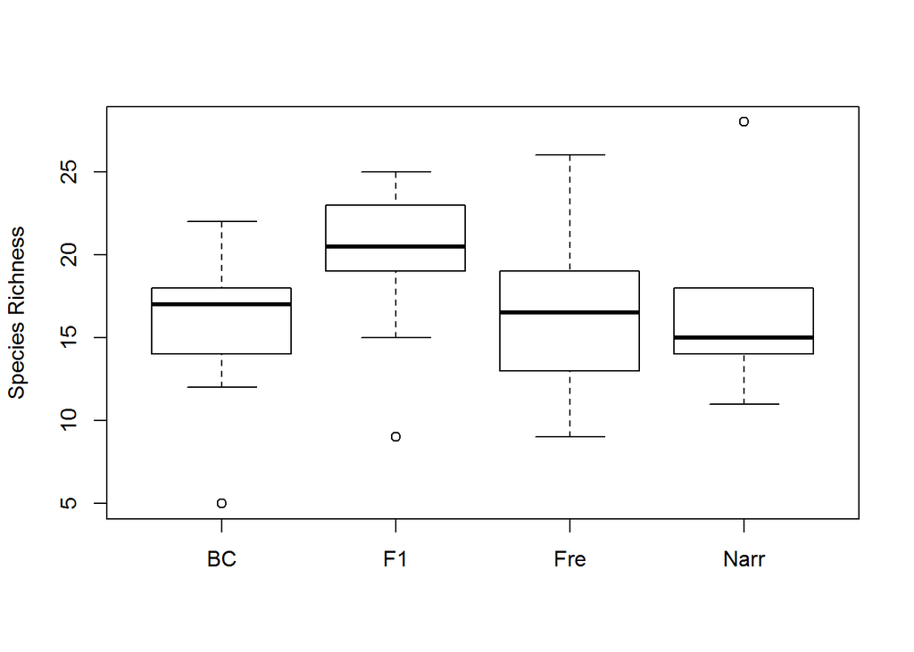

```r
treeCat=c(rep(c("Fre","F1","BC","Narr"),each=10))
boxplot(commSR~treeCat,ylab="Species Richness")
```

Are there significant differences in SR among tree types?

```r
summary(aov(commSR~treeCat))#nope!
```

```
##             Df Sum Sq Mean Sq F value Pr(>F)
## treeCat      3     99    32.9    1.41   0.26
## Residuals   36    841    23.4
```

Let’s save that species richness boxplot (Save it to your own folder, not the one below)

```r
tiff("U:/LOCKED/R_code/week03/Species_Richness_boxplot.tif",width=80,height=80,units="mm",res=150)
par(oma=c(0,0,0,0),mar=c(4,4,0,0))
boxplot(commSR~treeCat,xlab="Tree Type",ylab="Species Richness")
dev.off()
```

Now let’s do an analysis that is part of a package, vegan, that we have to download 1. Click on the “Packages” tab at right 2. Click the “Install” icon 3. Type in “vegan” (no quotes) and hit Enter

```r
library(vegan)
```

Let’s look at a species accumulation curve for our Freemont trees to assess whether our sampling was sufficient

```r
help(specaccum) #let's look at the parameters and outputs for this function
FremAccum=specaccum(t(FremDat),method="random",perm=100)
#Let's break this down
t(FremDat) #specaccum wants the dataset with species as columns and communities as rows; t(FremDat) is the transpose of our Freemont sub-dataset
```

[output not shown]

[output cut: 55 more lines]

[output not shown]

```r
FremAccum
```

```
## Species Accumulation Curve
## Accumulation method: random, with 100 permutations
## Call: specaccum(comm = t(FremDat), method = "random", permutations = 100)
##
##
## Sites     1.00  2.000  3.000  4.000  5.000  6.000  7.000  8.000  9.000 10
## Richness 16.33 27.050 34.600 40.510 45.880 50.400 54.660 58.460 62.510 66
## sd        4.30  5.002  4.665  4.291  3.677  3.548  3.102  2.548  1.772  0
```

```r
#This function randomly selects 1,2,...,10 samples 100 times, and calculates the mean and standard deviation of species richness
```

Let’s plot richness as a function of samples

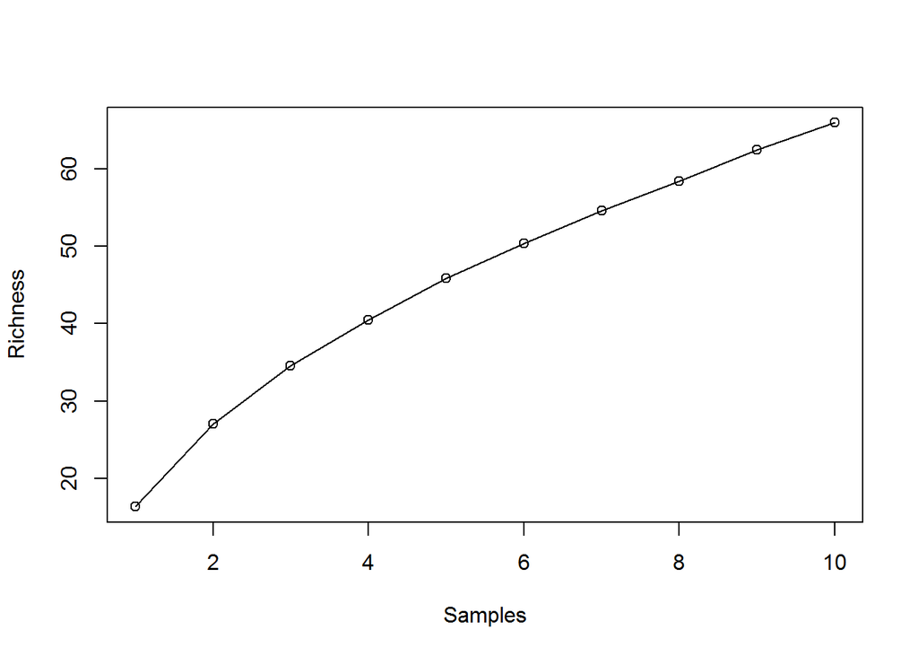

```r
plot(FremAccum$sites,FremAccum$richness,xlab="Samples",ylab="Richness") #looks like the species pool for Freemont was not fully sampled
#Let's connect the dots
lines(FremAccum$sites,FremAccum$richness)
```

Or we can be lazy and use in the built-in plot function for specaccum

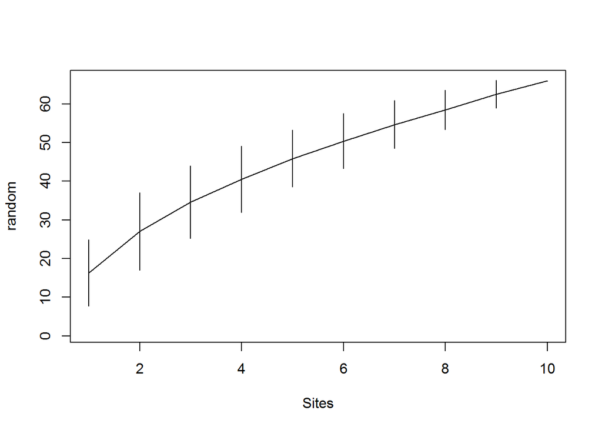

```r
plot(FremAccum)
```

Let’s see if we sufficiently sampled the “global” pool (species across all cottonwood types)

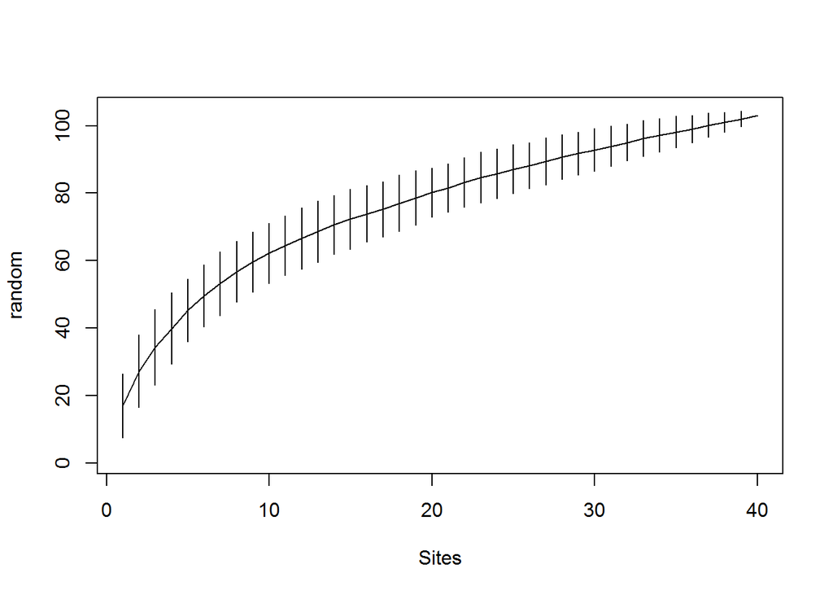

```r
AllAccum=specaccum(t(commDat[,-c(1:6)]),method="random",perm=100)
plot(AllAccum)
```

```r
#Still not hitting an asymptote; should have sampled more...
```

Let’s save this plot

```r
tiff("G:/LOCKED/R_code/week03/Species_Accum_Curve.tif",width=120,height=80,units="mm",res=150)
par(oma=c(0,0,0,0),mar=c(4,4,0,0))
plot(AllAccum)
dev.off()
```

That’s it for this week. Next week we’ll start playing with some new tools for visualizing and analyzing community structure.